# Your Digest for Wednesday, Oct 04, 2023 11:59 PM

- Neoplasia - lymphomas, myeloid neoplasms.
- Encrocrinopathies - Addison's disease

Causes can be classified as eosinophilia affecting multiple organs and eosinophilia affecting a particular (single) organ:

- Multiorgan involvement:
  - Allergies and asthma, DRESS [[General Pharmacology#Anticonvulsant hypersensitivity syndrome]]
  - Infections: helminths, ectoparasites like scabies, protozoans, fungi,
  - Neoplastic disorders
  - Immunologic disorders
    - Autoimmune - Sarcoidosis, IBD
- Organs specific (or organ limited) involvement:
  - Dematitis - atopic and many others
  - Sinonasal and pulmonary -> allergic rhinitis, asthma, chronic rhinosinusitis
  - GI -> eosinophilic oesophagitis
    - Adults present with strictures and dysphagia with a history of allergies
    - liver transplant rejection
  - Renal - drug induced nephritis, transplant rejection

## Consequences of eosinophilia

> [!WARNING] Activated eosinophils can damage organs  
> by release of granule contents, lipid mediators and cytokines.  
> But this usually occurs when the absolute eosinophil count > 1500 cell / microLiter

**Target organs** : any organ can be involved by the most commonly involved are the

- skin
- airways
- and GI tract  
  are the ones most commonly involved.

# SLE flare diagnosis

#2020GM-NOV/Q24  
[Source](https://www.ncbi.nlm.nih.gov/pmc/articles/PMC7045928/)  
SLE flares increase the risk of irreversible end organ damage. So, treatment and prevention of flares is important.

And SLE flare is mostly a clinical diagnosis. A flare is diagnosed after other 'flare mimics' (commonly infection) are **excluded.**

> [!TIP] *So the main concern is excluding other diseases before attributing symptoms to an SLE flare.*

> [!INFO] Features favoring actual SLE flare:
> - Low or only mildy elevated CRP
> - Leukopenia
> - Serology: low C3/C4, elevated anti-dsDNA
>   - During a flare, C3 and C4 are reduced.
>   - C4 may reduced *before* a flare while C3 is still normal [Source](https://www.ncbi.nlm.nih.gov/pmc/articles/PMC7045928/)
> - Fever which persists despite prednisolone therapy.
> - Flare of lupus nephritis: can be nephritic or nephrotic

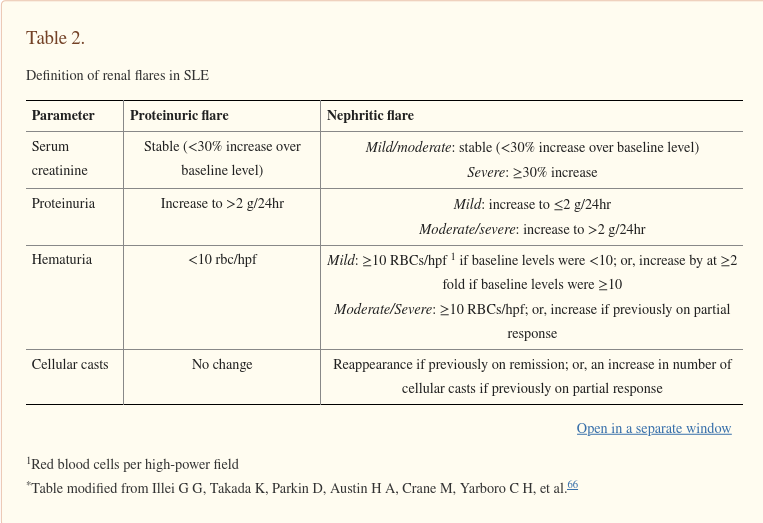

> [!INFO] SLE flare mimics and features suggesting them rather than SLE flare
> - Fibromyalgia
> - **Infection**:
>   - Fever with *chills + rigors*, *neutrophil leukocytosis*, band form of metamyelocytes on the blood film, *elevated CRP* (CRP is very non specific as it can rise with SLE synovitis or serositis)
>   - High procalcitonin is more specific for infection.
> - Drug reaction
>   - -? history
> - metabolic - like iron deficiency
>   - -? iron studies
> - Even malignancy
>   - -?

> [!INFO] When you want to exclude rheumamtoid arthritis as the diagnosis in a patient suspected to have SLE:  
> RF has less diagnostic utility, since *20 to 30 percent of people with SLE have a positive RF*. Anti-CCP antibodies, however, have a much higher specificity for RA and may be more useful for distinguishing the arthritis associated with RA

Signs of lupus flare (which may overlap with the mimics)

- Fever
- #TODO

## Serologic markers in SLE flares

- **anti dsDNA**(anti-dsDNA) is present in **50%** of SLE patients and titer corresponds with disease activity; especially nephritis. Rising anti-dsDNA may even precede a flare.
- **Anti-C1q** (antibodies to complement C1q) also along with anti-dsDNA. Assessing anti-C1a + anti-dsDNA together provides higher sensitivity and PPV for development of *flare with nephritis.*

## Fibromyalgia: SLE flare mimic

A patient education [Source](https://www.nhsinform.scot/illnesses-and-conditions/muscle-bone-and-joints/conditions/fibromyalgia)

- Female : male predominance 7:1
- Age 30 - 50 years
- Symptoms:
  - Pain all over the body
  - Stiffness
  - Poor sleep
  - Fatigue
  - IBS
- Probably caused by dysfunctional pain perception in the brain.
- Triggered by stressing events:
  - Infection, child birth, surgery, loss of loved one.
- Treatment:
  - Antidepressants and pain killers
  - Talking therapy
  - Lifestyle modification like exercise

# COPD exacerbation management:

A good explanation about the real reason why high Saturation is bad for COPD patients: [Source](https://litfl.com/oxygen-and-carbon-dioxide-retention-in-copd/)

COPD exacerbations are categorized as mild / moderate and severe - or life threatening.

1. Mild
2. Moderate
3. Severe - same as moderate but with acidosis.

Management of an exacerbation:

- assess severity:

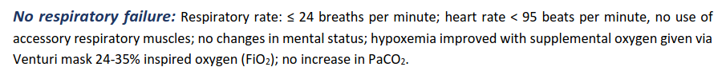

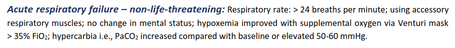

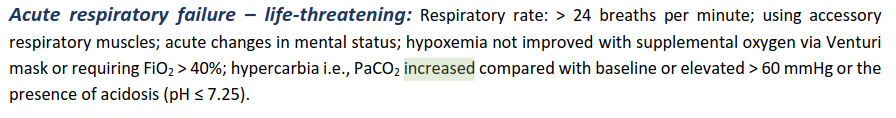

- Pharmacologic measures
  - Beta agonists and anticholinergics
  - Systemic steroids : oral is as effective as IV.-> They improve FEV1, reduce hospital stay and recovery duration.
  - Antibiotics when indicated.
    - **Methylxanthines** are not recommended due to the side effects.
    - **caffeine** is a methylxanthine; Methylxanthines (eg theophylline) have a narrow therapeutic index and side effects mimic effecs of caffeine; insomnia, polyuria, palpitations, increased GORD and gastric acid secretion. More severe toxicity can cause arrhythmias.
- Oxygen support:
  - Target SpO2 is 88-92%.
  - HFNO has been proven to reduce work of breathing and improve oxygenation. There is some evidence that it improves CO2 washout as well.
  - NIV is the preferred mod of ventilatory support if HFNO does not produce improvement.
    - There's no mention about the following points in guidelines but the internet book of critical care [Source](https://emcrit.org/ibcc/aecopd/#bipap) has reasonable explantions:
    - BiPAP is preferred because bilevel respiration is better for hypercapnic patient who need assistance with CO2 washout -> therefore, BiPAP is preferred in a COPD patient with respiratory acidosis.
    - CPAP improves oxygenagation but it not first line in COPD.
    - CO2 targets: Goal is to prevent CO2 rising and causing obtundation and coma; normal PaCO2 level may be detrimental as it will abolish the patients usual compensatory metabolic alkalosis, causing tachypnoea when support is weaned.

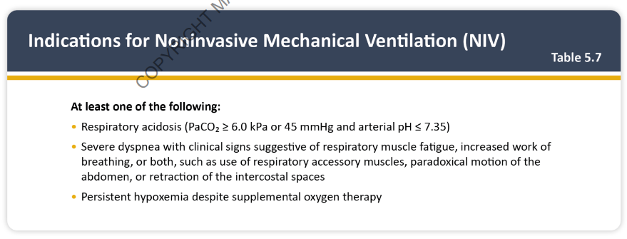

> [!INFO] Causes of **cyto protein dissociation in CSF**  
> AIDP  
> CIDP  
> SCPE  
> Lead poisoning

#2020GM-NOV/Q14

- **Burkholderia pseudomallei**
- facultative *intracellular* (facultative cos it can survive outside cells - in the environment as well)
- **Gram negative** (*n*egative - pi*n*k); Characteristic bipolar **safety-pin** appearance.
- An **environmental** organism. (as opposed to zoonosis - it's a *saprophyte*)
- **Extensive antibiotic resistance**
  - **characteristically resistant to *gentamicin***
- **Ceftazidime** works - but requires long course (2-4 weeks)
- followed by **months** of coamoxiclav / cotrimoxazole.  
  Exposure to soil and water.  
  Risk factors for severe disease: (i.e patient who have comorbidities)
- **Diabetes** - *particularly common*

#2020GM-NOV/Q18

###### At presentation:

- If SBP < 90 - 500 ml bolus within 15 minutes, and repeat. Usually 500 - 1000 ml is required.
- Once SPB > 90; give 1000ml over the next 60 minutes.
- If SBP > 90 at presentation
  - Give 1000 ml over 60 minutes.

Suggested fluid infusion rates for an otherwise healthy, 70kg adult

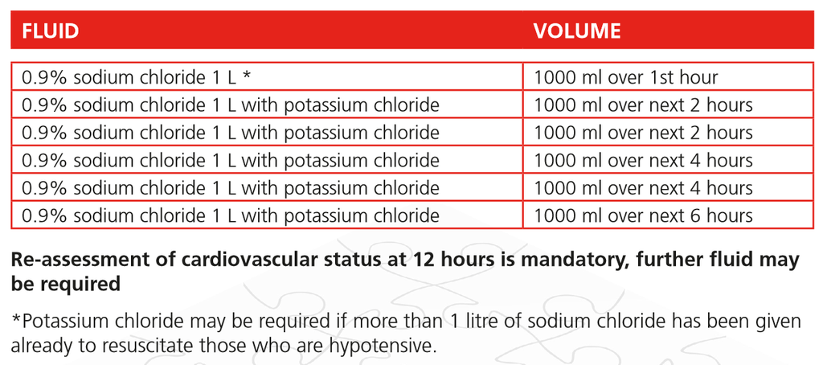

###### When to add dextrose infusion

- When glucose < 14 mmol/L (252mg/dL)
- Don't stop the insulin until criteria above are met.

#### Complications

**Pneumonia** is the commonest manifestation of legionella infection. Infection of other sites is rare.  
Can cause *mild to severe disease.*

- Associated **hyponatremia**
- *CRP > 100*;
- *GI symptoms*  
  Commonest manifestation is **upper** respiratory tract infection.  
  Most mycoplasma associated URTI and LRTI are mild and self limiting; They may not even need ABx. Pursuing a microbiological diagnosis usually isn't necessary as management won't change.

# Q fever: Coxiella burnetti

[figure not shown]

Zoonosis; commonest reservoir is goats, cattle, cats.  
Infective fluids come from anogenital systems : faeces, urine, birth products and milk.  
Infection is by inhalation of aerosols.  
Infection can cause:

- mild flu like illness
- Hepatitis
- Pneumonia  
  Chronic infection manifests as **endocarditis**

# Enterococcal infection

#2020GM-NOV/Q14

- Enterococci are commensals in the GI tract.
  - The two main human pathogens are enteroccus faecium and faecalis. Faecalis is more virulent but faecium can be resistant to vancomycin.
- Clinically context: they are associated with nosocomial infections mostly of **urinary tract**: catheter assocaited UTI, cystitis, pyelonephritis but also **infective indocarditis.**
- Treatment is difficult because they are resistant to many antibiotics.
  - They are resistant to penicillin and cephalosporins, macrolides, clindamycin, macrolides and TMP-SMX.
  - However, if sensitive, ampicillin and amoxicillin are the drugs of choice.
  - Vancomycin can be used if they are found to be sensitive.
  - Combination therapy with a **cell wall–active agent** (eg, ampicillin, vancomycin) and an **aminoglycoside** (eg, gentamicin, streptomycin) has long been regarded as the standard of care for *E faecalis* native valve endocarditis.

Streptococcus pneumoniae: Gram +ve coccus, alpha haemolytic.

## Pathophysiology:

#2020GM-NOV/Q12  
Coronary perfusion pressure is the gradient from end diastolic LV pressure to end diastolic aortic pressure. [Source](https://www.ahajournals.org/doi/10.1161/CIRCINTERVENTIONS.118.007547)

Infarction spreads outwards from the subendocardial (note: not endocardial, sub-endocardial) region because

- it receives the lowest flow from the coronaries
- It's perfusion pressure is reduced by the high intramural pressures.
- The contraction of myocardial fibers produces more resistance and blood displacement in the subendocardium than the subepicardium. [Source](https://www.ahajournals.org/doi/10.1161/CIRCINTERVENTIONS.118.007547)

> Illustrative point:  
> Both invasive and noninvasive studies have demonstrated increasing intramyocardial pressure from the epicardial to the endocardial surface of the ventricular wall.

Therefore, the **zone of infarction spreads outwards**.

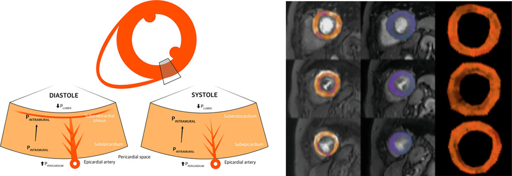

[Source](https://www.ahajournals.org/doi/10.1161/CIRCINTERVENTIONS.118.007547)

> ![INFO] However, the **resting myocardial blood flow** is **GREATEST IN THE SUBENDOCARDIUM**.

In LVH, there is preferential flow to the sub-epidardium rather than the subendocardium so that there is **reversal** of the *normal subendocardial to subepicardial* flow at rest.

Myocardial perfusion pressure decreases because of elevated LVEDP (secondary to decreased compliance)

> Myocardial perfusion is thus compromised by the relative decline in myocardial capillary density and by a reduced diastolic transmyocardial (coronary) perfusion gradient due to elevated LV diastolic pressure - [Source](https://emedicine.medscape.com/article/150638-overview#showall)

Resting coronary **flow** is increased (?due to compensatory effect of autoregulatory mechanism) but because of this, **coronary flow RESERVE** is reduced.

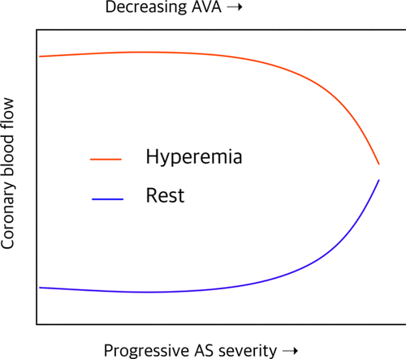

AVA - aortic valve area.  
[Source](https://www.ahajournals.org/doi/10.1161/CIRCINTERVENTIONS.118.007547#d1e1038)

[figure not shown]

> - the queen got chlamydia from a bartender in lagos. :P

## Common pathogens:

#2020GM-NOV/Q14

> [!INFO] "Atypical"  
> atypical" refers to the
> 1. intrinsic resistance of these organisms to beta-lactams
> 2. and their inability to be visualized on Gram stain or cultured using traditional techniques
- Streptococcus pneumonia is the commonest cause.

| Typicals | Atypicals | Examples | Comment |
| --- | --- | --- | --- |
| Strep pneumoniae |  |  | Most common |
| Haemophillus influenzae |  |  | Fastidious, facultative anaerobic, G - coccobacilli |
| Moraxella catarrhalis |  |  | Obligate aerobic, G - coccus |
| Staph aureus |  |  | Coagulate +ve, G +ve coccus |
| Group A strep |  | S. pyogenes | Catalase -ve, G +ve cocci |
| Aerobic gram Negs |  | E. Coli, Klebsiella | Both are enterobacteriacea |
| Microaerophillic |  | campylobacter etc | Associated with aspiration |
| ------ | ------ | ------ | ------ |
|  | [[Misc infectious diseases#Legionella pneumonia\|legionella]] |  |  |
|  | [[Misc infectious diseases#Mycoplasma pneumonia\|mycoplasma]] |  |  |
|  | Chlamydia pneumonia and chlamydia psittaci |  |  |
|  | Coxiella burnetti |  |  |

**And also viruses:**

- Influenza A and B
- Rhinoviruses
- Corona viruses
- adenoviruses and many more.

> [!TIP] Key Role of eosinophils  
> Approximately 50% of asthma cases are attributable to eosinophilic airway inflammation [17-19]. Eosinophilic airway inflammation results from the activation of mast cells and antigen-specific Th2 cells resulting in the production of cytokines and up-regulation of epithelial inducible nitric oxide (NO)  
> [Source](https://www.ncbi.nlm.nih.gov/pmc/articles/PMC3826517/)
- #2020GM-NOV/Q19
- Nitric oxide acts in the lungs to dilate both airways and blood vessels.
- In asthma, epithelial cells **produce NO** probably to *counteract the narrowing caused by other mediators.*
- Exhaled NO can be used as a marker of the degree of *eosinophillic airway inflammation*. ->
- **Exhaled NO increases in asthma**.
- The test is called FENA: fractional exhaled nitric oxide.
- Higher FENA **predicts better response to inhaled corticosteroid** therapy. [Source](https://pubmed.ncbi.nlm.nih.gov/15901605/)

### Role of pulmonary rehabilitation

#2020GM-NOV/Q19  
Pulmonary rehabilitation has traditionally been used for COPD with good evidence supporting its use.  
However, newer evidence supports use in asthma as well.

- [Source](https://www.uptodate.com/contents/pulmonary-rehabilitation)
- [Source](https://www.asthmaandlung.org.uk/living-with/keeping-active/pulmonary-rehabilitation)
- [Source](https://www.ncbi.nlm.nih.gov/pmc/articles/PMC7219266/)